# Assignment 1

Cornelia

2024-09-22

# TASK 1

### NUMBER 1

Mobile genetic element variants (MEVs) can influence gene expression and be used in genome-wide association studies (GWAS) to identify potential causes of the development of diseases.

### NUMBER 2

MEGAnE

### NUMBER 3

1. How do MEVs interact with environmental factors to influence disease risk?
2. Are there age differences related to MEVs and their contributions to disease risk?
3. Will we find similar findings in European populations?

### NUMBER 4

1. Incorporating environmental factors data (e.g., pollution, diet) and applying statistical models to investigate their interactions.
2. Statistical analyses stratified by age.
3. Conducting studies among European populations.

# TASK 2 and 3

Setting up R and packages

```r
install.packages("tidyverse")
install.packages("svglite")

if (!require("BiocManager", quietly = TRUE)) #install Bioconductor for analysis of high-throughput genomic data
  install.packages("BiocManager")
BiocManager::install(version = "3.19")

BiocManager::install(c("GenomicFeatures", "AnnotationDbi"))
```

```r
library(tidyverse)
library(svglite)
library(BiocManager)
```

# TASK 4

### Number 1

```r
data(CO2) #load the data
```

### Number 2

```r
?CO2
```

```
## starting httpd help server ... done
```

### Number 3

```r
# The average and median CO2 uptake in Quebec (median 37.15; mean 33.54)

summary(CO2$uptake [CO2$Type %in% "Quebec"])
```

```
##    Min. 1st Qu.  Median    Mean 3rd Qu.    Max.
##    9.30   30.32   37.15   33.54   40.15   45.50
```

```r
# The average and median CO2 uptake in Mississippi (median 19.30; mean 20.88)

summary(CO2$uptake [CO2$Type %in% "Mississippi"])
```

```
##    Min. 1st Qu.  Median    Mean 3rd Qu.    Max.
##    7.70   13.88   19.30   20.88   28.05   35.50
```

### Number 4

```r
BiocManager::install("airway")
browseVignettes("airway")
??airway
```

```r
library("airway")
data(airway)
str(airway)
```

[output not shown]

[output cut: 77 more lines]

```
##   .. .. .. ..@ contact          : chr ""
##   .. .. .. ..@ title            : chr "RNA-Seq transcriptome profiling identifies CRISPLD2 as a glucocorticoid responsive gene that modulates cytokine"| __truncated__
##   .. .. .. ..@ abstract         : chr "Asthma is a chronic inflammatory respiratory disease that affects over 300 million people worldwide. Glucocorti"| __truncated__
##   .. .. .. ..@ url              : chr "http://www.ncbi.nlm.nih.gov/pubmed/24926665"
##   .. .. .. ..@ pubMedIds        : chr "24926665"
##   .. .. .. ..@ samples          : list()
##   .. .. .. ..@ hybridizations   : list()
##   .. .. .. ..@ normControls     : list()
##   .. .. .. ..@ preprocessing    : list()
##   .. .. .. ..@ other            : list()
##   .. .. .. ..@ .__classVersion__:Formal class 'Versions' [package "Biobase"] with 1 slot
##   .. .. .. .. .. ..@ .Data:List of 2
##   .. .. .. .. .. .. ..$ : int [1:3] 1 0 0
##   .. .. .. .. .. .. ..$ : int [1:3] 1 1 0
##   .. .. .. .. .. ..$ names: chr [1:2] "MIAxE" "MIAME"
```

```r
dim(airway)
```

```
## [1] 63677     8
```

```r
airway_assay <- data.frame(assay(airway)) #extract the gene expression

dim(airway_assay)  #to see the number of genes and samples
```

```
## [1] 63677     8
```

```r
str(airway_assay)  #to see the structure of the matrix
```

```
## 'data.frame':    63677 obs. of  8 variables:
##  $ SRR1039508: int  679 0 467 260 60 0 3251 1433 519 394 ...
##  $ SRR1039509: int  448 0 515 211 55 0 3679 1062 380 236 ...
##  $ SRR1039512: int  873 0 621 263 40 2 6177 1733 595 464 ...
##  $ SRR1039513: int  408 0 365 164 35 0 4252 881 493 175 ...
##  $ SRR1039516: int  1138 0 587 245 78 1 6721 1424 820 658 ...
##  $ SRR1039517: int  1047 0 799 331 63 0 11027 1439 714 584 ...
##  $ SRR1039520: int  770 0 417 233 76 0 5176 1359 696 360 ...
##  $ SRR1039521: int  572 0 508 229 60 0 7995 1109 704 269 ...
```

```r
# count the number of genes not expressed (zero values) in any sample
airway_assay$total_notexp <- rowSums(airway_assay[, 1:8] == 0)
table(airway_assay$total_notexp, useNA = "always") #30208 genes are not expressed in any of sample
```

```
##
##     0     1     2     3     4     5     6     7     8  <NA>
## 18870  1694  1366  1339  1437  1751  2420  4592 30208     0
```

```r
# count the number of genes expressed (non-zero values) in each sample (column) using lapply
genes_exp_list <- lapply(1:8, function(i) sum(airway_assay[, i] != 0))
genes_exp <- unlist(genes_exp_list)  #convert to vector

print(genes_exp) #the number of genes expressed in each sample = 24633, 24527, 25699, 23124, 25508, 25998, 24662, 23991
```

```
## [1] 24633 24527 25699 23124 25508 25998 24662 23991
```

# TASK 5

### Number 1

```r
a = c(1:100)

ratio_mean_median <- function(x) {
  # to check if the input is a numeric vector
  if (!is.numeric(x) || !is.vector(x)) {
    stop("Input must be a numeric vector.") # using ELSE is unnecessary because the stop() function will terminate the execution if the condition is met
  }
  ratio <- mean(x, na.rm = TRUE) / median(x, na.rm = TRUE)
  print(ratio)
}
ratio_mean_median(a)
```

```
## [1] 1
```

### Number 2

```r
ratio_mean <- function(x) {
  # to check if the input is a numeric vector
  if (!is.numeric(x) || !is.vector(x)) {
    stop("Input must be a numeric vector.") # using ELSE is unnecessary because the stop() function will terminate the execution if the condition is met
  }
  x_tot <- x[x != min(x, na.rm = TRUE) & x != max(x, na.rm = TRUE)]

  print(summary(x))
  print(summary(x_tot))
  print(mean(x_tot, na.rm = TRUE))
}
ratio_mean(a)
```

```
##    Min. 1st Qu.  Median    Mean 3rd Qu.    Max.
##    1.00   25.75   50.50   50.50   75.25  100.00
##    Min. 1st Qu.  Median    Mean 3rd Qu.    Max.
##    2.00   26.25   50.50   50.50   74.75   99.00
## [1] 50.5
```

### Number 3

Why: to write easy-to-read-and-understand codes.  
How: pipe uses “lexical transformation”; focuses verb not noun.  
Not to use: pipes with >10 steps (difficult to debug); have multiple inputs or outputs; graph with complex dependency structure.

### Number 4

The apply family is to reduce the need of loop creation.  
apply() for matrices and data frames.  
lapply() for lists; output as list.  
sapply() for lists; output as value (simplified).  
tapply() for vectors.

# TASK 6

```r
install.packages("remotes")
```

```r
library(remotes)
```

```r
install_url("http://emotion.utu.fi/wp-content/uploads/2019/11/nummenmaa_1.0.tar.gz",dependencies=TRUE)
```

### Number 1A

```r
magic_guys <- read.csv(paste0(folder, "magic_guys.csv"))

table(magic_guys$species, useNA = "always")
```

```
##
## jedi sith <NA>
##   50   50    0
```

```r
### USING HIST FUNCTION

##### SPECIES 1

min(magic_guys$length [magic_guys$species %in% "jedi"]) #60.1
```

```
## [1] 60.1
```

```r
max(magic_guys$length [magic_guys$species %in% "jedi"]) #272.9
```

```
## [1] 272.9
```

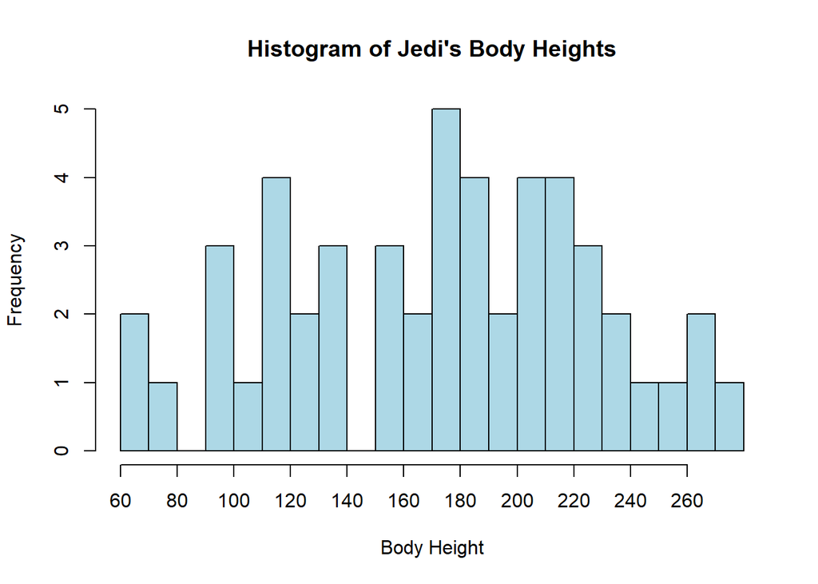

```r
hist(magic_guys$length [magic_guys$species %in% "jedi"],
     main = "Histogram of Jedi's Body Heights",
     xlab = "Body Height",
     col = "lightblue",
     breaks = 20, #to create bin
     xaxt = 'n') #to remove the default of x-axis label
axis(1, at = seq(60, 273, by = 20)) #to add new x-axis label based on min and max values
```

```r
##### SPECIES 2

min(magic_guys$length [magic_guys$species %in% "sith"]) #69.4
```

```
## [1] 69.4
```

```r
max(magic_guys$length [magic_guys$species %in% "sith"]) #179.1
```

```
## [1] 179.1
```

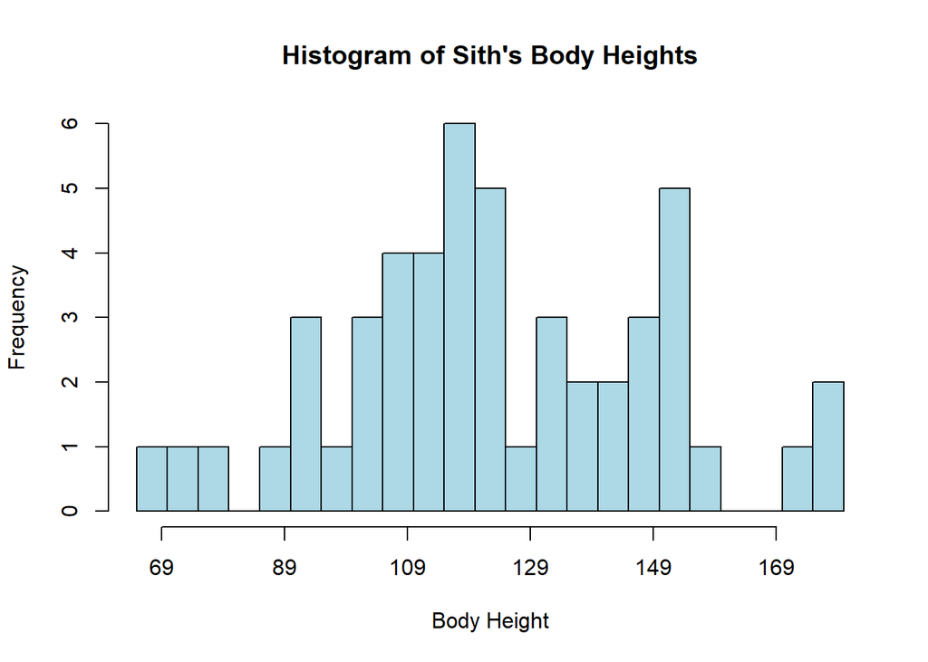

```r
hist(magic_guys$length [magic_guys$species %in% "sith"],
     main = "Histogram of Sith's Body Heights",
     xlab = "Body Height",
     col = "lightblue",
     breaks = 20, #to create bin
     xaxt = 'n') #to remove the default of x-axis label
axis(1, at = seq(69, 179, by = 20)) #to add new x-axis label based on min and max values
```

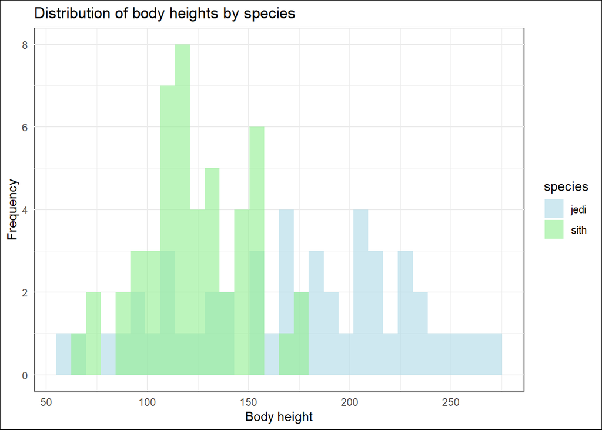

```r
### USING GGPLOT FUNCTION

body_height_geomhisto <- ggplot(magic_guys, aes(x = length, fill = species)) +
                            geom_histogram(position = "identity", alpha = 0.6, bins = 30) +
                            labs(title = "Distribution of body heights by species",
                                 x = "Body height",
                                 y = "Frequency") +
                            scale_fill_manual(values = c("lightblue", "lightgreen")) +
                            theme_minimal() +
                            theme(plot.background = element_rect(fill = "white"),  #set plot background to white
                                  panel.background = element_rect(fill = "white"))  #set panel background to white
print(body_height_geomhisto)
```

### Number 1B

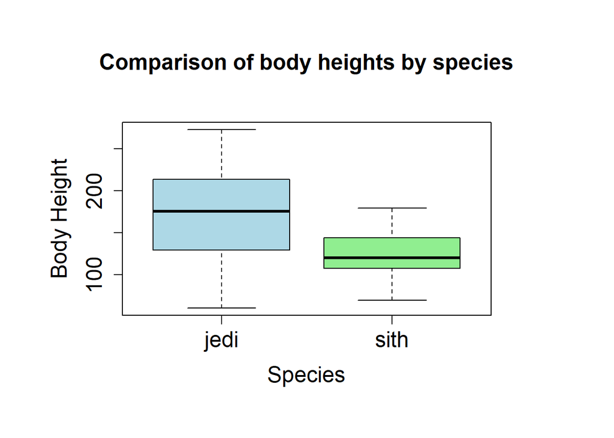

```r
### USING BOXPLOT FUNCTION

par(mar = c(7, 7, 7, 7))  #adjust margins if necessary
boxplot(length ~ species,
        data = magic_guys,
        main = "Comparison of body heights by species",
        xlab = "Species",
        ylab = "Body Height",
        col = c("lightblue", "lightgreen"),
        cex = 1.5,          #general text size
        cex.axis = 1.5,     #axis tick labels size
        cex.lab = 1.5,      #axis labels size
        cex.main = 1.5)     #main title size)
```

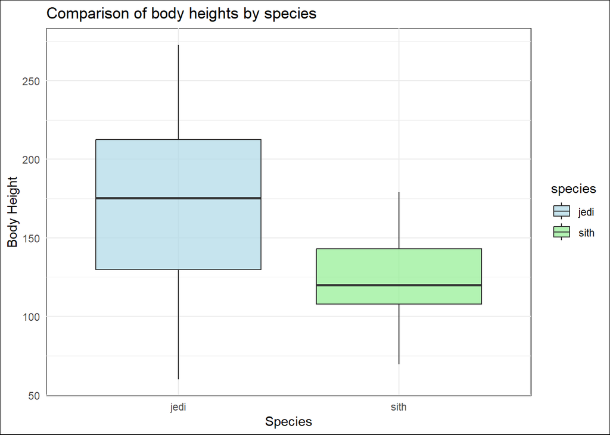

```r
body_height_geombox <- ggplot(magic_guys, aes(x = species, y = length, fill = species)) +
                                geom_boxplot(alpha = 0.7) +
                                labs(title = "Comparison of body heights by species",
                                     x = "Species",
                                     y = "Body Height") +
                                scale_fill_manual(values = c("lightblue", "lightgreen")) +
                                theme_minimal() +
                                theme(plot.background = element_rect(fill = "white"),  #set plot background to white
                                      panel.background = element_rect(fill = "white"))  #set panel background to white
print(body_height_geombox)
```

### Number 1C

PNG is for web use or digital presentations (no scaling needed).  
PDF is for print outputs or embedded in documents.  
SVG is for web-based applications (scaling needed).

```r
### HISTOGRAM

##### FOR JEDI'S BODY HEIGHT

#list of file formats and their corresponding functions
formats_jedi <- list(
  png = function() png("Jedi_body_height_histogram.png", width = 800, height = 600),
  pdf = function() pdf("Jedi_body_height_histogram.pdf", width = 8, height = 6),
  svg = function() svg("Jedi_body_height_histogram.svg", width = 8, height = 6)
)

#generate and save the histogram in multiple formats
lapply(formats_jedi, function(f) {
  f()  #call the function to open the device
    hist(magic_guys$length [magic_guys$species %in% "jedi"],
     main = "Histogram of Jedi's Body Heights",
     xlab = "Body Height",
     col = "lightblue",
     breaks = 20, #to create bin
     xaxt = 'n') #to remove the default of x-axis label
    axis(1, at = seq(60, 273, by = 20)) #to add new x-axis label
  dev.off()  #close the device
})

##### FOR SITH'S BODY HEIGHT

#list of file formats and their corresponding functions
formats_sith <- list(
  png = function() png("Sith_body_height_histogram.png", width = 800, height = 600),
  pdf = function() pdf("Sith_body_height_histogram.pdf", width = 8, height = 6),
  svg = function() svg("Sith_body_height_histogram.svg", width = 8, height = 6)
)

#generate and save the histogram in multiple formats
lapply(formats_sith, function(f) {
  f()  #call the function to open the device
    hist(magic_guys$length [magic_guys$species %in% "sith"],
     main = "Histogram of Sith's Body Heights",
     xlab = "Body Height",
     col = "lightblue",
     breaks = 20, #to create bin
     xaxt = 'n') #to remove the default of x-axis label
    axis(1, at = seq(60, 273, by = 20)) #to add new x-axis label
  dev.off()  #close the device
})

ggsave("body_height_geomhisto.png", plot = body_height_geomhisto, width = 8, height = 6, dpi = 300) #using ggplot
ggsave("body_height_geomhisto.pdf", plot = body_height_geomhisto, width = 8, height = 6) #using ggplot
ggsave("body_height_geomhisto.svg", plot = body_height_geomhisto, width = 8, height = 6) #using ggplot


### BOXPLOT

#list of file formats and their corresponding functions
formats_box <- list(
  png = function() png("body_height_bloxplot.png", width = 800, height = 600),
  pdf = function() pdf("body_height_bloxplot.pdf", width = 8, height = 6),
  svg = function() svg("body_height_bloxplot.svg", width = 8, height = 6)
)

#generate and save the boxplots in multiple formats
lapply(formats_box, function(f) {
  f()  #call the function to open the device
    par(mar = c(7, 7, 7, 7))  #adjust margins if necessary
    boxplot(length ~ species,
        data = magic_guys,
        main = "Comparison of body heights by species",
        xlab = "Species",
        ylab = "Body Height",
        col = c("lightblue", "lightgreen"),
        cex = 2,          #general text size
        cex.axis = 2,     #axis tick labels size
        cex.lab = 2,      #axis labels size
        cex.main = 2)     #main title size)
  dev.off()  #close the device
})

ggsave("body_height_geombox.png", plot = body_height_geombox, width = 8, height = 6, dpi = 300) #using ggplot
ggsave("body_height_geombox.pdf", plot = body_height_geombox, width = 8, height = 6) #using ggplot
ggsave("body_height_geombox.svg", plot = body_height_geombox, width = 8, height = 6) #using ggplot
```

### Number 2A

```r
microarray_data <- read.delim(paste0(folder, "microarray_data.tab"))

dim(microarray_data) #553 rows; 1000 columns
```

```
## [1]  553 1000
```

### Number 2B

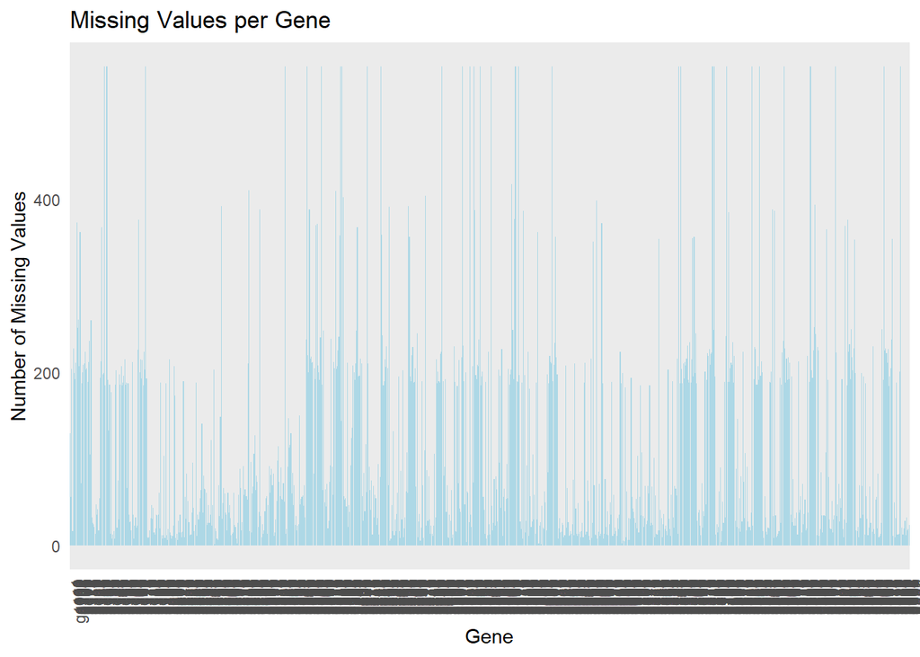

```r
missing_genes_data <- data.frame(gene = names(colSums(is.na(microarray_data))), missingvalues = colSums(is.na(microarray_data)))

#visualize the count of missing values
ggplot(missing_genes_data, aes(x = gene, y = missingvalues)) +
  geom_bar(stat = "identity", fill = "lightblue") +
  labs(title = "Missing Values per Gene", x = "Gene", y = "Number of Missing Values") +
  theme_minimal() +
  theme(axis.text.x = element_text(angle = 90, hjust = 1))  # Rotate x-axis labels for better visibility
```

### Number 2C

```r
missing_genes_data <- missing_genes_data %>%
  mutate(percent_missing = missingvalues / 553 * 100)

missing_genes_data <- missing_genes_data %>%
  mutate(X = case_when(percent_missing > 10.000 ~ 10,
                       percent_missing > 20.000 ~ 20,
                       percent_missing > 50.000 ~ 50,
                       TRUE ~ NA ))

table(missing_genes_data$gene [missing_genes_data$X == 10], useNA = "always")
```

```
##
##   g1  g10 g100 g101 g102 g103 g104 g105 g106 g107 g108 g109  g11 g110 g111 g112
##    1    1    1    1    1    1    1    1    1    1    1    1    1    1    1    1
## g113 g114 g115 g116 g117 g118 g119  g12 g120 g130 g131 g132 g133 g134 g135 g136
##    1    1    1    1    1    1    1    1    1    1    1    1    1    1    1    1
## g137 g138 g139  g14 g140 g142 g147 g148  g15 g151 g152 g153 g154 g155 g156 g157
##    1    1    1    1    1    1    1    1    1    1    1    1    1    1    1    1
## g158 g159  g16 g160 g165 g171 g172 g173 g174 g175 g176 g177 g178 g179  g18 g180
##    1    1    1    1    1    1    1    1    1    1    1    1    1    1    1    1
## g194 g196   g2 g200 g204  g21 g210  g22 g221 g223  g23 g233 g239  g24 g241 g242
##    1    1    1    1    1    1    1    1    1    1    1    1    1    1    1    1
## g243 g244  g25 g252 g258  g26 g260 g263 g264 g268 g274  g28 g280 g281 g284 g285
##    1    1    1    1    1    1    1    1    1    1    1    1    1    1    1    1
## g286 g287 g288  g29 g290 g292 g294 g295 g296 g297 g298 g299   g3 g301 g309 g311
##    1    1    1    1    1    1    1    1    1    1    1    1    1    1    1    1
## g312 g313 g314 g315 g316 g320 g321 g322 g323 g324 g327 g329 g331 g332 g333 g334
##    1    1    1    1    1    1    1    1    1    1    1    1    1    1    1    1
## g335 g336 g337 g339 g344 g347 g348  g35 g351 g352 g353 g354 g355 g356 g357 g358
##    1    1    1    1    1    1    1    1    1    1    1    1    1    1    1    1
## g359  g36 g360 g361 g362 g363 g364 g365 g366 g367 g368 g369  g37 g370 g372 g374
##    1    1    1    1    1    1    1    1    1    1    1    1    1    1    1    1
## g377 g378 g379  g38 g380 g381 g382 g383 g384 g385 g386 g387 g388 g389  g39 g390
##    1    1    1    1    1    1    1    1    1    1    1    1    1    1    1    1
## g391 g392 g396   g4  g40 g400 g401 g402 g403 g404 g405 g406 g407 g408 g409  g41
##    1    1    1    1    1    1    1    1    1    1    1    1    1    1    1    1
## g410 g411 g413 g415 g416 g417 g418 g419  g42 g421 g423 g425 g429 g430 g431 g432
##    1    1    1    1    1    1    1    1    1    1    1    1    1    1    1    1
## g433 g434 g435 g436 g437 g438 g439  g44 g440 g445  g45 g450 g453 g455 g459  g46
##    1    1    1    1    1    1    1    1    1    1    1    1    1    1    1    1
## g460 g461 g462 g463 g464 g465 g466 g467 g468 g469  g47 g470 g476 g477 g479  g48
##    1    1    1    1    1    1    1    1    1    1    1    1    1    1    1    1
## g481 g483  g49 g491 g492 g493 g494 g495 g496 g497 g498 g499   g5  g50 g500 g502
##    1    1    1    1    1    1    1    1    1    1    1    1    1    1    1    1
## g507  g51 g510 g513 g514 g515 g518 g519  g52 g520 g522 g524 g525 g527  g53 g530
##    1    1    1    1    1    1    1    1    1    1    1    1    1    1    1    1
## g531 g532 g533 g534 g535 g536 g537 g538 g539  g54 g540 g541 g544 g547  g55 g553
##    1    1    1    1    1    1    1    1    1    1    1    1    1    1    1    1
## g555 g556 g558 g559  g56 g561 g563 g564 g567 g569  g57 g570 g571 g572 g573 g574
##    1    1    1    1    1    1    1    1    1    1    1    1    1    1    1    1
## g575 g576 g577 g578 g579  g58 g580 g583 g585 g586 g589  g59 g591 g592 g595 g597
```

[output cut: 14 more lines]

```
##    1    1    1    1    1    1    1    1    1    1    1    1    1    1    1    1
## g820 g822 g824  g83 g831 g832 g833 g834 g835 g836 g837 g838 g839  g84 g840 g843
##    1    1    1    1    1    1    1    1    1    1    1    1    1    1    1    1
## g849  g85 g850 g851 g854  g86 g861 g862 g863 g864 g865 g866 g867 g868 g869  g87
##    1    1    1    1    1    1    1    1    1    1    1    1    1    1    1    1
## g870 g872 g874  g88 g882 g884  g89 g891 g892 g893 g894 g895 g896 g897 g898 g899
##    1    1    1    1    1    1    1    1    1    1    1    1    1    1    1    1
##  g90 g900 g903 g909  g91 g910 g911 g919  g92 g922 g926  g93 g931 g932 g933 g934
##    1    1    1    1    1    1    1    1    1    1    1    1    1    1    1    1
## g935 g936 g937 g938 g939  g94 g940 g945 g947 g948  g95 g951 g952 g956  g96 g963
##    1    1    1    1    1    1    1    1    1    1    1    1    1    1    1    1
## g965  g97 g970 g971 g972 g973 g974 g975 g976 g977 g978 g979  g98 g980 g985 g989
##    1    1    1    1    1    1    1    1    1    1    1    1    1    1    1    1
##  g99 <NA>
##    1  471
```

```r
table(missing_genes_data$gene [missing_genes_data$X == 20], useNA = "always")
```

```
##
## <NA>
##  471
```

```r
table(missing_genes_data$gene [missing_genes_data$X == 50], useNA = "always")
```

```
##
## <NA>
##  471
```

### NUMBER 2D

```r
gen = paste0("g", c(1:1000))

for (i in gen) {
    mean_value <- mean(microarray_data[, i], na.rm = TRUE)  #calculate mean, ignoring NAs
    microarray_data[is.na(microarray_data[, i]), i] <- mean_value
}
```

### NUMBER 3

```r
summary(CO2)
```

```
##      Plant             Type         Treatment       conc          uptake
##  Qn1    : 7   Quebec     :42   nonchilled:42   Min.   :  95   Min.   : 7.70
##  Qn2    : 7   Mississippi:42   chilled   :42   1st Qu.: 175   1st Qu.:17.90
##  Qn3    : 7                                    Median : 350   Median :28.30
##  Qc1    : 7                                    Mean   : 435   Mean   :27.21
##  Qc3    : 7                                    3rd Qu.: 675   3rd Qu.:37.12
##  Qc2    : 7                                    Max.   :1000   Max.   :45.50
##  (Other):42
```

```r
summary(CO2$uptake)
```

```
##    Min. 1st Qu.  Median    Mean 3rd Qu.    Max.
##    7.70   17.90   28.30   27.21   37.12   45.50
```

```r
summary(CO2$conc)
```

```
##    Min. 1st Qu.  Median    Mean 3rd Qu.    Max.
##      95     175     350     435     675    1000
```

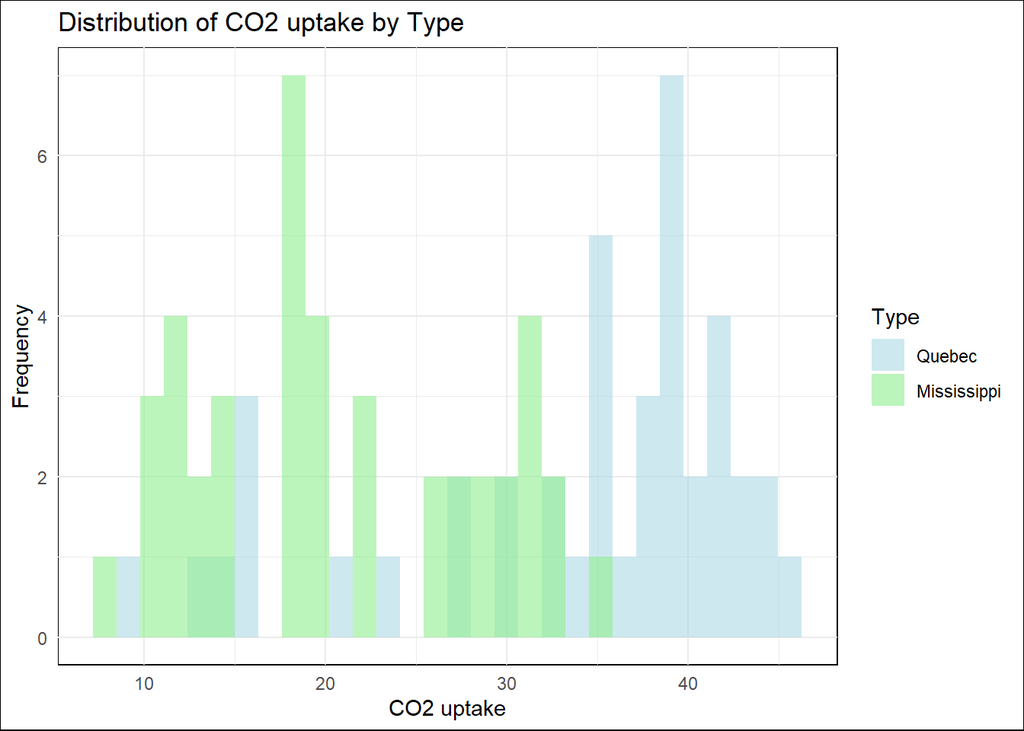

```r
ggplot(CO2, aes(x = uptake, fill = Type)) +
  geom_histogram(position = "identity", alpha = 0.6, bins = 30) +
  labs(title = "Distribution of CO2 uptake by Type",
  x = "CO2 uptake",
  y = "Frequency") +
  scale_fill_manual(values = c("lightblue", "lightgreen")) +
  theme_minimal() +
  theme(plot.background = element_rect(fill = "white"),  #set plot background to white
        panel.background = element_rect(fill = "white"))  #set panel background to white
```

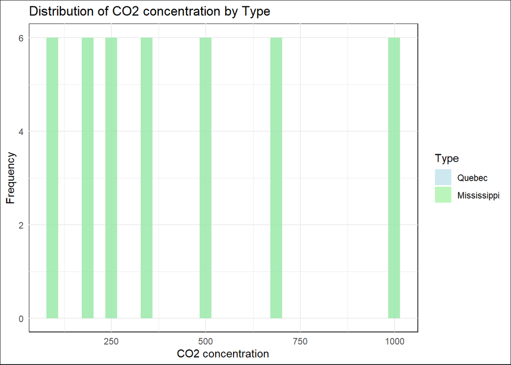

```r
ggplot(CO2, aes(x = conc, fill = Type)) + #CO2 concentrations are the same for both cities
  geom_histogram(position = "identity", alpha = 0.6, bins = 30) +
  labs(title = "Distribution of CO2 concentration by Type",
  x = "CO2 concentration",
  y = "Frequency") +
  scale_fill_manual(values = c("lightblue", "lightgreen")) +
  theme_minimal() +
  theme(plot.background = element_rect(fill = "white"),  #set plot background to white
        panel.background = element_rect(fill = "white"))  #set panel background to white
```

# TASK 7

```r
install.packages("devtools")
```

```r
library(devtools)
```

```r
devtools::install_github("hirscheylab/tidybiology")
```

```r
library("tidybiology")
```

### NUMBER 1A

```r
### CHROMOSOME DATA
data(chromosome)
dim(chromosome)
```

```
## [1] 24 14
```

```r
summary_stats_chr <- chromosome %>%
  summarize(
    mean_variations = mean(variations, na.rm = TRUE),
    median_variations = median(variations, na.rm = TRUE),
    max_variations = max(variations, na.rm = TRUE),

    mean_protein_coding_genes = mean(protein_codinggenes, na.rm = TRUE),
    median_protein_coding_genes = median(protein_codinggenes, na.rm = TRUE),
    max_protein_coding_genes = max(protein_codinggenes, na.rm = TRUE),

    mean_miRNAs = mean(mi_rna, na.rm = TRUE),
    median_miRNAs = median(mi_rna, na.rm = TRUE),
    max_miRNAs = max(mi_rna, na.rm = TRUE)
  )
```

### NUMBER 1B

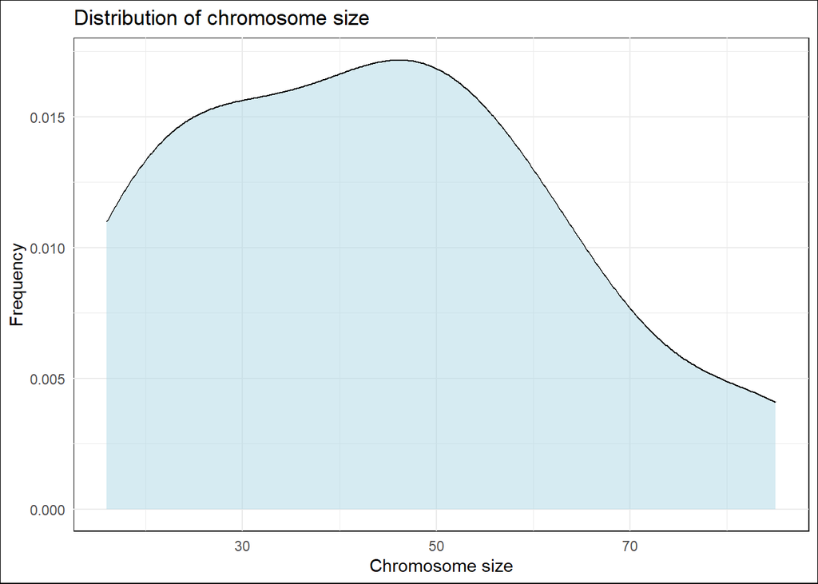

```r
ggplot(chromosome, aes(x = length_mm)) +
  geom_density(fill = "lightblue", alpha = 0.5) +
  #geom_histogram(position = "identity", alpha = 0.6, bins = 30) +
  labs(title = "Distribution of chromosome size",
       x = "Chromosome size",
       y = "Frequency") +
  theme_minimal() +
  theme(plot.background = element_rect(fill = "white"),  #set plot background to white
        panel.background = element_rect(fill = "white"))  #set panel background to white
```

### NUMBER 1C

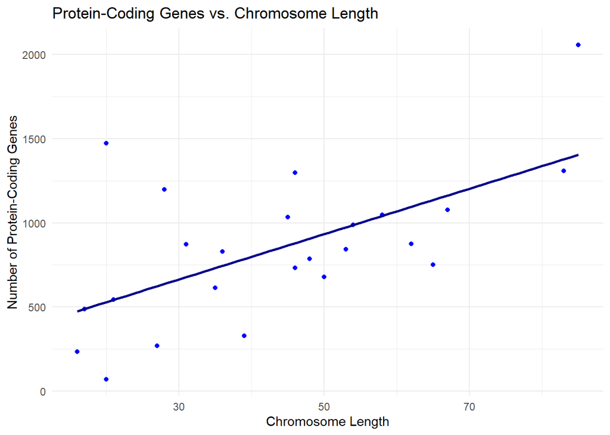

```r
#Plot for protein-coding genes vs. chromosome length
ggplot(chromosome, aes(x = length_mm, y = protein_codinggenes)) +
  geom_point(color = "blue") +
  geom_smooth(method = "lm", se = FALSE, color = "darkblue") +  #adds a linear trend line
  labs(title = "Protein-Coding Genes vs. Chromosome Length",
       x = "Chromosome Length",
       y = "Number of Protein-Coding Genes") +
  theme_minimal()
```

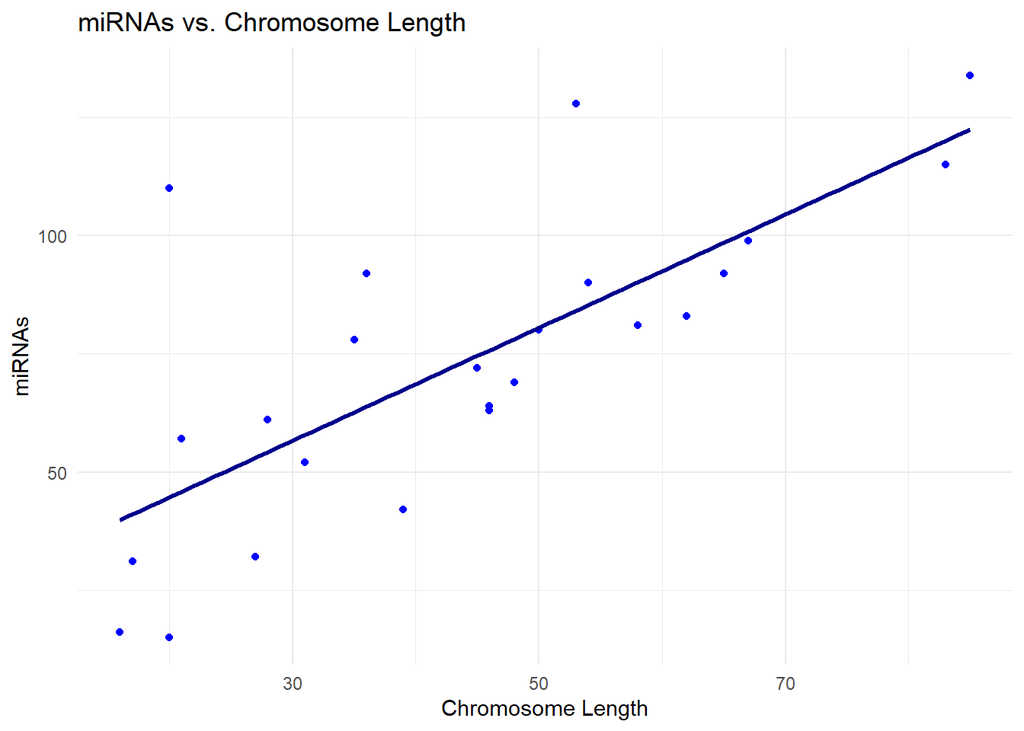

```r
#Plot for mi_RNA vs. chromosome length
ggplot(chromosome, aes(x = length_mm, y = mi_rna)) +
  geom_point(color = "blue") +
  geom_smooth(method = "lm", se = FALSE, color = "darkblue") +  #adds a linear trend line
  labs(title = "miRNAs vs. Chromosome Length",
       x = "Chromosome Length",
       y = "miRNAs") +
  theme_minimal()
```

```r
cor(chromosome$length_mm, chromosome$protein_codinggenes, use = "complete.obs") #0.6060185
```

```
## [1] 0.6060185
```

```r
cor(chromosome$length_mm, chromosome$mi_rna, use = "complete.obs") #0.7366973
```

```
## [1] 0.7366973
```

### NUMBER 1D

```r
### PROTEIN DATA

data(proteins)
dim(proteins)
```

```
## [1] 20430     8
```

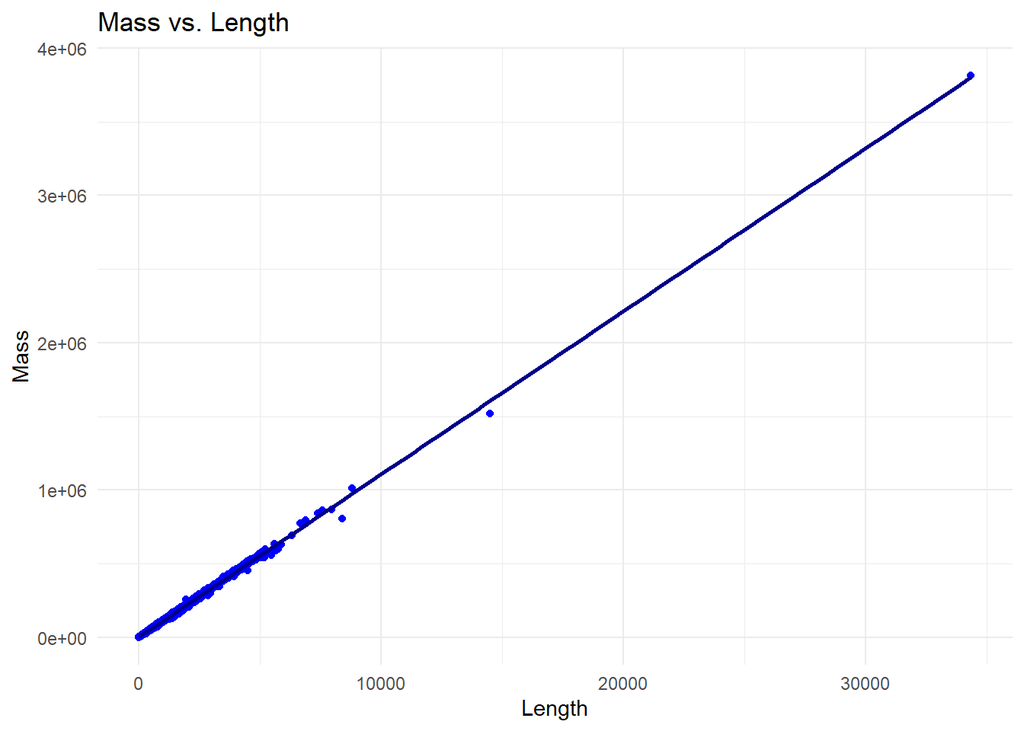

```r
summary_stats_protein <- proteins %>%
  summarize(
    mean_length = mean(length, na.rm = TRUE),
    median_length = median(length, na.rm = TRUE),
    max_length = max(length, na.rm = TRUE),

    mean_mass = mean(mass, na.rm = TRUE),
    median_mass = median(mass, na.rm = TRUE),
    max_mass = max(mass, na.rm = TRUE),
  )

#Plot for mass vs. chromosome length
ggplot(proteins, aes(x = length, y = mass)) +
  geom_point(color = "blue") +
  geom_smooth(method = "lm", se = FALSE, color = "darkblue") +  #adds a linear trend line
  labs(title = "Mass vs. Length",
       x = "Length",
       y = "Mass") +
  theme_minimal()
```

```r
cor(proteins$length, proteins$mass, use = "complete.obs") #0.9991674
```

```
## [1] 0.9991674
```